# Unemployment in the US: How to Predict and build a model of it

## Building models

OLS Linear Regression The first one, and most popular way to predict some changes is to build linear regression model, based on Ordinary least squares method of modelling changes. OLS model will allow us to predict the way of Unemployment change. Summary of the model says, all the variables are somehow connected and Adjusted R-squared is very high. Also, residual standard error is small, which is very good. There is also big amount of degrees of freedom.

```r
ols <- lm(UNEMP~REALGDP + REALCONS + REALINVS + REALGOVT + TBILRATE + REALINT + M1 + CPI_U + POP + INFL, data=UN_data)
summary(ols)
```

```
Call:
lm(formula = UNEMP ~ REALGDP + REALCONS + REALINVS + REALGOVT +
    TBILRATE + REALINT + M1 + CPI_U + POP + INFL, data = UN_data)

Residuals:
     Min       1Q   Median       3Q      Max
-0.98813 -0.31174 -0.02158  0.25227  1.60271

Coefficients:
              Estimate Std. Error t value Pr(>|t|)
(Intercept) -1.861e+01  1.366e+00 -13.627  < 2e-16 ***
REALGDP     -6.574e-03  1.079e-03  -6.090 5.98e-09 ***
REALCONS     6.737e-03  1.217e-03   5.536 1.00e-07 ***
REALINVS    -4.375e-03  1.019e-03  -4.295 2.77e-05 ***
REALGOVT    -9.417e-03  1.082e-03  -8.700 1.45e-15 ***
TBILRATE     8.947e-01  4.801e-01   1.864   0.0639 .
REALINT     -1.064e+00  4.831e-01  -2.202   0.0288 *
M1          -8.835e-03  9.844e-04  -8.975 2.51e-16 ***
CPI_U        3.550e-02  2.784e-03  12.752  < 2e-16 ***
POP          2.021e-01  1.094e-02  18.471  < 2e-16 ***
INFL        -1.077e+00  4.801e-01  -2.243   0.0260 *
---
Signif. codes:  0 ‘***’ 0.001 ‘**’ 0.01 ‘*’ 0.05 ‘.’ 0.1 ‘ ’ 1

Residual standard error: 0.5042 on 193 degrees of freedom
Multiple R-squared:  0.9026,    Adjusted R-squared:  0.8976
F-statistic: 178.9 on 10 and 193 DF,  p-value: < 2.2e-16
```

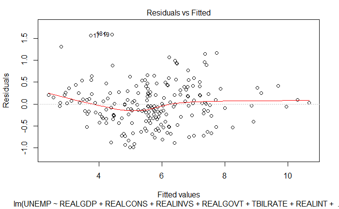

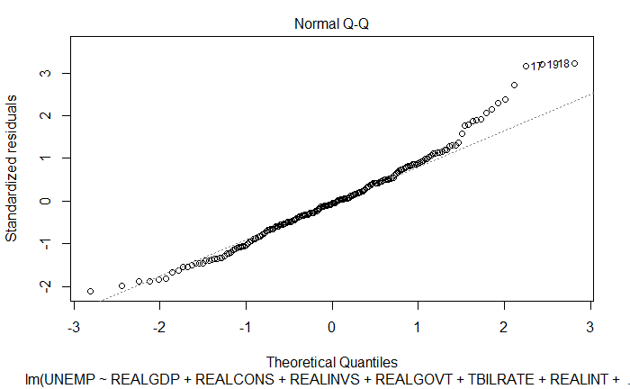

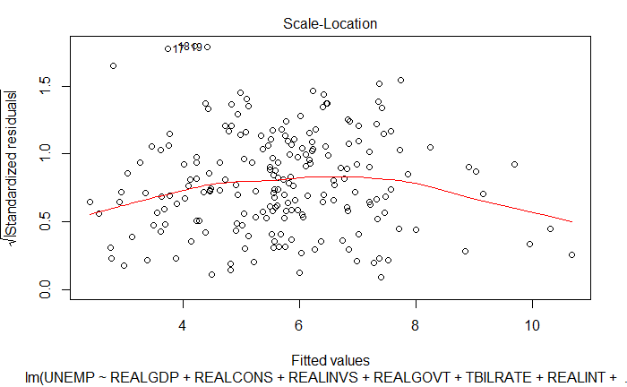

```
NaNs producedNaNs produced
```

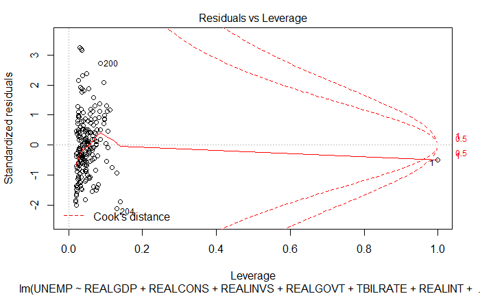

```r
plot(ols)
```

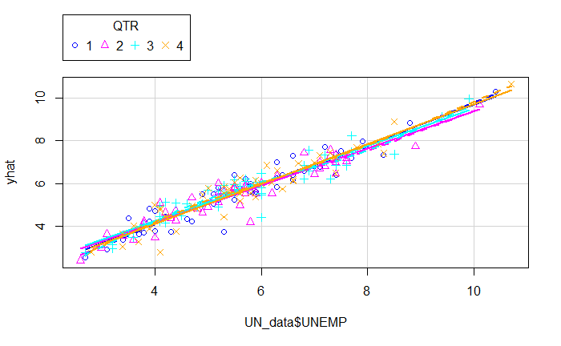

```r
yhat <- ols$fitted
scatterplot(yhat~UN_data$UNEMP|QTR, boxplots=FALSE)
```

```r
model.fe <-plm(UNEMP~ QTR +REALGDP + REALCONS + REALINVS + REALGOVT + TBILRATE + REALINT + M1 + CPI_U + POP + INFL, data = UN_data, model = 'within')
summary(model.fe)
```

```
Oneway (individual) effect Within Model

Call:
plm(formula = UNEMP ~ QTR + REALGDP + REALCONS + REALINVS + REALGOVT +
    TBILRATE + REALINT + M1 + CPI_U + POP + INFL, data = UN_data,
    model = "within")

Balanced Panel: n = 51, T = 4, N = 204

Residuals:
      Min.    1st Qu.     Median    3rd Qu.       Max.
-0.6562417 -0.1220914 -0.0082607  0.1087741  0.6282654

Coefficients:
            Estimate  Std. Error t-value  Pr(>|t|)
QTR2      0.10851827  0.06947027  1.5621 0.1205263
QTR3      0.15885207  0.11128411  1.4274 0.1556781
QTR4      0.23726606  0.15519506  1.5288 0.1285642
REALGDP  -0.00466246  0.00183166 -2.5455 0.0119956 *
REALCONS  0.00056458  0.00172987  0.3264 0.7446306
REALINVS -0.00010544  0.00201774 -0.0523 0.9583977
REALGOVT -0.00074643  0.00194203 -0.3844 0.7012994
TBILRATE  0.99672402  0.25015179  3.9845 0.0001083 ***
REALINT  -1.15057590  0.25278859 -4.5515 1.146e-05 ***
M1       -0.00182785  0.00189254 -0.9658 0.3357989
CPI_U     0.02545247  0.00869143  2.9285 0.0039778 **
POP       0.05156239  0.06498884  0.7934 0.4288853
INFL     -1.16915902  0.24940663 -4.6878 6.483e-06 ***
---
Signif. codes:  0 ‘***’ 0.001 ‘**’ 0.01 ‘*’ 0.05 ‘.’ 0.1 ‘ ’ 1

Total Sum of Squares:    20.075
Residual Sum of Squares: 7.1333
R-Squared:      0.64467
Adj. R-Squared: 0.48477
F-statistic: 19.5382 on 13 and 140 DF, p-value: < 2.22e-16
```

Modelling Linear random effects regression model.  
RE model is necessarily to check, in case we have panel data.  
- Adjusted R-squaredgot bigger  
- Observing the same proclivity: Consumption, Investment are not important ones.  
Further we will perform some diagnostics (including Hausman test for stat. significanse) and test, which model is better.

```r
model.rm <-plm(UNEMP~QTR +REALGDP + REALCONS + REALINVS + REALGOVT + TBILRATE + REALINT + M1 + CPI_U + POP + INFL, data = UN_data, model = 'random')
summary(model.rm)
```

```
Oneway (individual) effect Random Effect Model
   (Swamy-Arora's transformation)

Call:
plm(formula = UNEMP ~ QTR + REALGDP + REALCONS + REALINVS + REALGOVT +
    TBILRATE + REALINT + M1 + CPI_U + POP + INFL, data = UN_data,
    model = "random")

Balanced Panel: n = 51, T = 4, N = 204

Effects:
                  var std.dev share
idiosyncratic 0.05095 0.22573 0.203
individual    0.20002 0.44723 0.797
theta: 0.7553

Residuals:
     Min.   1st Qu.    Median   3rd Qu.      Max.
-0.590354 -0.164774 -0.045947  0.139426  0.840144

Coefficients:
               Estimate  Std. Error z-value  Pr(>|z|)
(Intercept) -19.3436620   1.9679219 -9.8295 < 2.2e-16 ***
QTR2          0.0305854   0.0514217  0.5948  0.551980
QTR3         -0.0277864   0.0514837 -0.5397  0.589395
QTR4         -0.0212899   0.0538107 -0.3956  0.692367
REALGDP      -0.0042448   0.0013740 -3.0894  0.002005 **
REALCONS      0.0016732   0.0013869  1.2064  0.227659
REALINVS     -0.0021929   0.0014092 -1.5561  0.119675
REALGOVT     -0.0057537   0.0014774 -3.8945 9.838e-05 ***
TBILRATE      1.1139831   0.2772740  4.0176 5.879e-05 ***
REALINT      -1.2629602   0.2799757 -4.5110 6.453e-06 ***
M1           -0.0065547   0.0012967 -5.0550 4.303e-07 ***
CPI_U         0.0341348   0.0036705  9.2998 < 2.2e-16 ***
POP           0.1992193   0.0160076 12.4453 < 2.2e-16 ***
INFL         -1.2753834   0.2766036 -4.6109 4.010e-06 ***
---
Signif. codes:  0 ‘***’ 0.001 ‘**’ 0.01 ‘*’ 0.05 ‘.’ 0.1 ‘ ’ 1

Total Sum of Squares:    49.032
Residual Sum of Squares: 12.423
R-Squared:      0.74665
Adj. R-Squared: 0.72931
Chisq: 559.937 on 13 DF, p-value: < 2.22e-16
```